# The Tone of Persuasion: Emotions in Personal Stories about Controversial Issues

Combatting historic polarization in America can feel fruitless as the left and the right march relentlessly apart and the tone of social engagement deteriorates. Even as the internet facilitates aggressive, anonymous attacks and even Russian-orchestrated arguments about non-events, it provides us with the richest insight ever into how people do learn and change their minds. In this analysis, we used internet data to provide some insight into how we can start conversations with each other that lead us back toward consensus and compromise.

As the theme, of the analysis, we chose one of the most divisive and emotional issues in America: abortion. We wanted to know what about a conversation about this issue can lead to an authentic exchange. That people are persuaded by “stories” is a truism in messaging for advocacy. Intuitively, it *feels* true that people should be persuaded by authentic stories they can relate to rather the by cold facts. But it is easy to the emotional power of a personal story backfiring; because emotion is so powerful, its power to repel may be as great as its power to attract. This is especially true when the reader or listener comes to the subject with powerful emotions of their own.

We were interested in what kinds of conversations sprang from personal accounts of the process of deciding whether or not to have an abortion. Thousands of such stories appear in the user forums at Babycenter. For this analysis, we coded parts of 350+ stories and the conversations that followed.

Because these stories are about the decision process–few involved decisions already made–they offer a unique perspective into the intersection of politics and personal experience.

# Certain Tones Helped Elicit Empathetic Response or Protect against Unsupportive Response

We analyzed post tone using [IBM’s Tone Analyzer](https://www.ibm.com/watson/services/tone-analyzer/) and then coded the first response to each post to see what kind of conversation it started.

Almost all the personal stories were from women considering whether to continue or terminate a pregnancy; many asked for advice. Because we were interested in whether the personal stories affected their readers, we coded the responses from the readers into three categories:

- empathy: support and uncertainty or observations about the poster’s specific situation (e.g. “It sounds like a terrible situation”,“It doesn’t sound like you want to…”)
- supportive: support for the decision process but a recommendation based on the respondent’s existing perspective (e.g., “Have you considered adoption. I am adopted”, “I had an abortion and never regretted it”, “No one regrets having a baby”)
- unsupportive: direct rejection

Most responses to personal stories posts were supportive.

Posts that result in a direct rejection may be framed in a way that closes rather than opens conversations. In addition, however, posts that result in empathy or uncertainty on the reader’s part may have features that make them close enough to the reader’s personal experience to potentially open avenues to a change of perspective in favor of or against abortion.

The chart below shows how the different tones (each post could have a combination of any of these) affected the responses that followed. A few of these differences were significant (n=361):

- Posts with less joy and less anger resulted in more empathy
- Posts that were more analytical–presenting more specific facts about the personal situation–were less likely to encounter direct rejection.

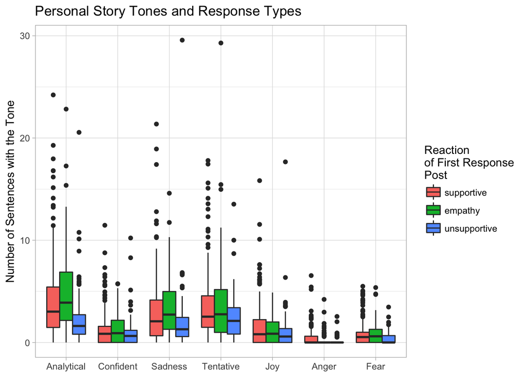

# “Just the Facts” May Be a Powerful Approach

More analytics stories led to more analytical responses. That doesn’t mean that they led to more persuasion, but analytical thinking along with sadness are low arousal states of mind, and the mind does process complex or conflicting information better when it is less agitated.

The chart below shows how the tones of original stories related to the tones of up to 10 following posts for 75 conversation threads. Green means a positive correlation so that a more fearful original story led to more fearful followup posts, for instance. Red means a negative correlation so that more fearful original stories led to *less* angry followup posts.

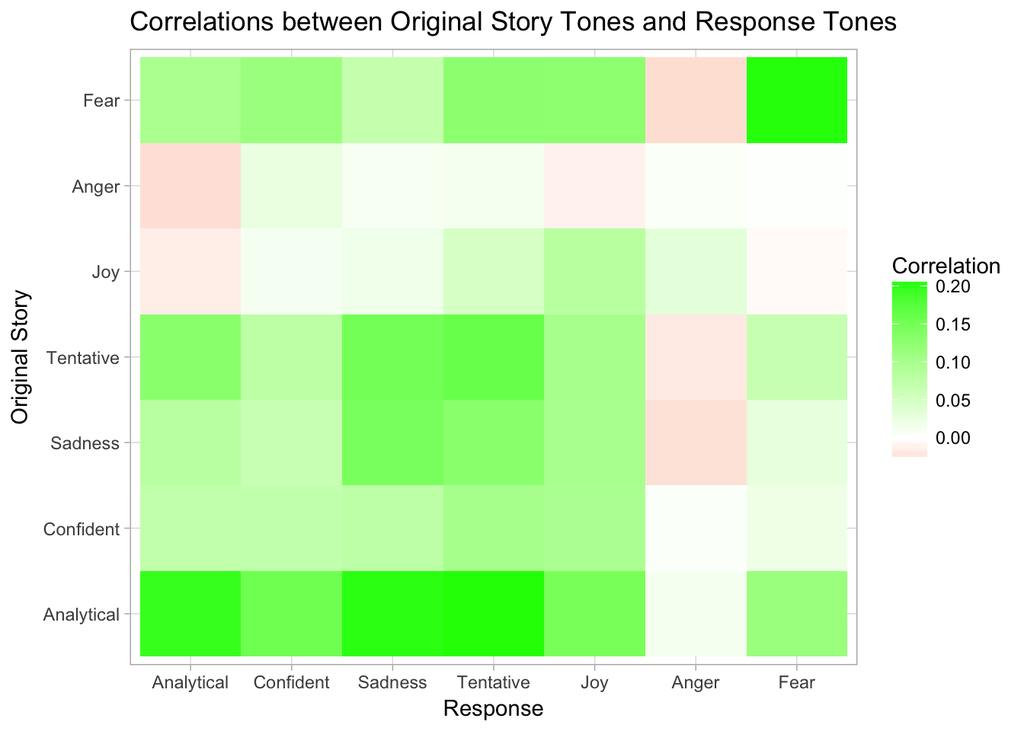

Analytical opening stories led to analytical, sad, and tentative followup messages. All these lower arousal emotions may reflect a more contemplative exchange.

## Joy and Redemption May Also Be Important Themes

It may seem surprising that any of these posts included “Joy”. Posts with Joy also carried other emotions such as Fear and Sadness, and these posts were very often stories from women who had struggled terribly and found relief through happier relationships or new stability. Some of these women found themselves pregnant before they felt established in their new happiness, and some were from women who had had abortions in the past and were celebrating new, wanted pregnancies (a very common theme in conversations about choice is the fear that abortion may lead to infertility).

While Joy didn’t directly lead to more empathetic first responses, it did lead to more Joyful conversations. There may be an opportunity to bring two very disparate sides together on this divisive issue through a shared value for children and family.

# What to Do with All This

This analysis, like all “found-data” analyses to a certain extent, only gives us hints about what could work. Indeed, the sample here is very small, which is easily remedied with more time and resources, and made up almost exclusively of conversations between women, which can only be addressed through more formally designed research.

Big data and its statistical methods hold much more promise for helping us understand how people think and communicate about complex social issues. Here, we focused on tone analysis, but Natural Language Processing methods can also give us insights to major themes and even to syntax choices, and formal network analysis can illuminate who talks to whom when and how.

We can think of this exercise as a large-scale focus group. The analysis can help us generate hypotheses to explore using more discrete methods such as quantitative surveys and experiments, and as we learn more from those efforts, we can return to these big, messy qualtitative data.